# Pitcher card

# Cole Ragans

LHP · KC

2026 · 8 G (8 GS) · 638 pitches · Mar 27 – May 06, 2026

Independent portfolio sample by Devin Jenkinson, not affiliated with any club. Every number is computed from public Statcast data.

Three big takeaways

1Attack

The 4-seam fastball is the put-away pitch. Use it to finish at-bats.

59% of two-strike pitches · 33% whiffs/swing (70 swings)

It grades 99 Stuff+. No other pitch has 50+ two-strike swings yet.

2Avoid

xRV/100 -0.55 shrunk (raw -1.82) · .457 xwOBAcon · 105 pitches

When behind in the count he throws it 19% of the time; the 4-seam fastball grades +0.40 there instead.

3Watch

Use the 4-seam fastball up in the zone. It beats the league rate there.

36% whiffs/swing up (100 sw) vs 28% MLB FF up

52% of his 4-seam fastballs finish in the top third. Too few swings down (20) to compare.

Charts

### Movement

The KC finishes 39 in from his FF, with 32 in less rise.

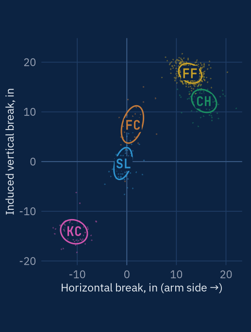

n = 638 pitches. Ellipses hold about 68% of each type; codes sit at the averages.

### Location by count

He throws 50% of pitches in the zone when behind and 46% when ahead.

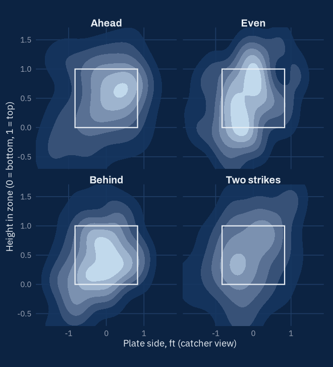

n = 638. Ahead 71 · even 215 · behind 155 · two strikes 197 pitches. Box = rule-book zone.

### Put-away

The FF is 59% of two-strike pitches vs 56% overall.

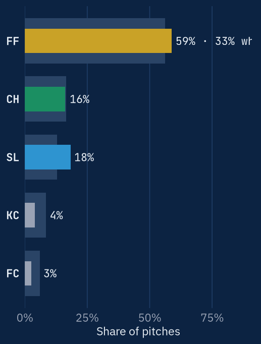

Two-strike n: FF 116, SL 36, CH 32, KC 8, FC 5. Grey bars = overall usage; wh = whiffs per swing (shown with 50+ swings).

### Arsenal

| Pitch | # | Use | Velo | IVB | HB | VAA | Whiff | Chase | xwOBAcon | xRV/100 | Stuff+ |
| --- | --- | --- | --- | --- | --- | --- | --- | --- | --- | --- | --- |
| 4-Seam (FF) | 358 | 56% | 94.9 | 17.8 | +12.8 | -5.1 | 31% | 26% | .372 | +0.40 | 99 |
| Changeup (CH) | 105 | 16% | 84.2 | 12.2 | +15.5 | -7.3 | 40% | 32% | .457 | -0.55 | 102 |
| Slider (SL) | 83 | 13% | 85.0 | -0.4 | -0.6 | -8.7 | 37% | 35% | .404 | -0.24 | 99 |
| Knuckle Curve (KC) | 54 | 8% | 79.3 | -14.0 | -10.6 | -10.4 | 12% | 13% | 1.193 | -1.26 | 94 |
| Cutter (FC) | 38 | 6% | 89.7 | 7.4 | +1.2 | -6.8 | 21% | 40% | .239 | -0.12 | 84 |

IVB / HB in inches (HB + = arm side). VAA in degrees at the front of the plate. xRV/100 = expected run value per 100 pitches, pitcher’s view, shrunk with a 250-pitch prior. Stuff+ = this project’s shape-only model (100 = MLB average, 10 = 1 SD).

### Vs. batter hand

| Pitch | LHH # | Use | Whiff | xwOBAcon | RHH # | Use | Whiff | xwOBAcon |
| --- | --- | --- | --- | --- | --- | --- | --- | --- |
| FF | 129 | 62% | 21% | .379 | 229 | 53% | 35% | .272 |
| CH | 5 | 2% | – | .000 | 100 | 23% | 40% | .348 |
| SL | 50 | 24% | – | .436 | 33 | 8% | – | .131 |
| KC | 6 | 3% | – | – | 48 | 11% | – | 1.111 |
| FC | 18 | 9% | – | .357 | 20 | 5% | – | .283 |

Use = share of pitches to that side. Whiff = whiffs per swing, shown with 50+ swings.